# Chapter 2: Regression and model validation

This week started our journey to regression analysis with simple and multiple linear models. Ways of validating the models graphically are also used.

## Data description

This week, we’ll be working on survey data to understand connections between the attitudes and motivations of students with their performance in an exam. The data is from 2014 and is collected by Kimmo Vehkalahti. [Full metadata description is provided here.](https://www.mv.helsinki.fi/home/kvehkala/JYTmooc/JYTOPKYS3-meta.txt)

Since the original data includes tens of variables, the data has been preprocessed by collapsing the answers to many Likert-scaled claims to single answers by theme. For example, the variable “stra” represents the mean of answers related to “Study strategy”.

Let’s read in the data and explore its structure:

```r
library(dplyr)
library(readr)
df <- read_csv("data/learning2014.csv", show_col_types = FALSE)
str(df)
```

```
## spc_tbl_ [166 × 7] (S3: spec_tbl_df/tbl_df/tbl/data.frame)
##  $ gender  : chr [1:166] "F" "M" "F" "M" ...
##  $ age     : num [1:166] 53 55 49 53 49 38 50 37 37 42 ...
##  $ attitude: num [1:166] 3.7 3.1 2.5 3.5 3.7 3.8 3.5 2.9 3.8 2.1 ...
##  $ deep    : num [1:166] 3.58 2.92 3.5 3.5 3.67 ...
##  $ stra    : num [1:166] 3.38 2.75 3.62 3.12 3.62 ...
##  $ surf    : num [1:166] 2.58 3.17 2.25 2.25 2.83 ...
##  $ points  : num [1:166] 25 12 24 10 22 21 21 31 24 26 ...
##  - attr(*, "spec")=
##   .. cols(
##   ..   gender = col_character(),
##   ..   age = col_double(),
##   ..   attitude = col_double(),
##   ..   deep = col_double(),
##   ..   stra = col_double(),
##   ..   surf = col_double(),
##   ..   points = col_double()
##   .. )
##  - attr(*, "problems")=<externalptr>
```

```r
dim(df)
```

```
## [1] 166   7
```

#### Interpretation:

Cool! There are 166 observations (rows) and 7 variables (columns). The variables are all numerical save for gender, which is a binary character (F/M). Points tells the exam performance of that student and is our target variable.

## Data overview

Let’s start with a more thorough exploration of the variables. It’s important to know the distribution of the variables and their interconnections. As a reminder, the task is to predict exam performance from survey results that try to capture the study strategies and attitudes of students.

Let’s therefore create a graphical representation of the variables and a summary statistics table.

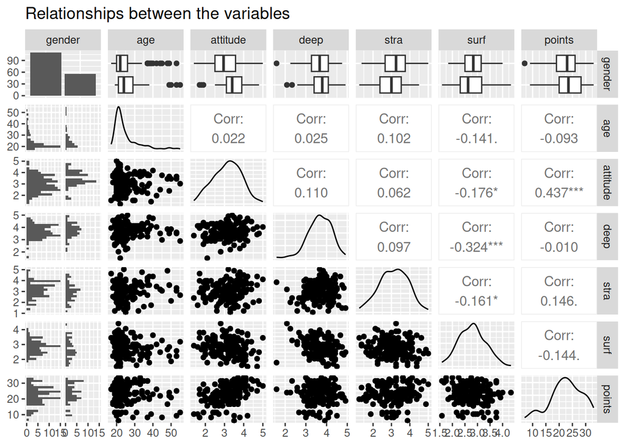

```r
# calling the GGally and ggplot2 libraries
library(GGally)
library(ggplot2)

# creating a plot matrix to explore the distribution of the variables and the relationships between them.
p <- ggpairs(df, mapping = aes(), title="Relationships between the variables", progress = FALSE, lower = list(combo = wrap("facethist", bins = 20)))

# draw the plot
p
```

```r
# summary stats of the numerical columns
summary(dplyr::select(df, -c(gender)))
```

```
##       age           attitude          deep            stra
##  Min.   :17.00   Min.   :1.400   Min.   :1.583   Min.   :1.250
##  1st Qu.:21.00   1st Qu.:2.600   1st Qu.:3.333   1st Qu.:2.625
##  Median :22.00   Median :3.200   Median :3.667   Median :3.188
##  Mean   :25.51   Mean   :3.143   Mean   :3.680   Mean   :3.121
##  3rd Qu.:27.00   3rd Qu.:3.700   3rd Qu.:4.083   3rd Qu.:3.625
##  Max.   :55.00   Max.   :5.000   Max.   :4.917   Max.   :5.000
##       surf           points
##  Min.   :1.583   Min.   : 7.00
##  1st Qu.:2.417   1st Qu.:19.00
##  Median :2.833   Median :23.00
##  Mean   :2.787   Mean   :22.72
##  3rd Qu.:3.167   3rd Qu.:27.75
##  Max.   :4.333   Max.   :33.00
```

```r
# counts per gender
table(df$gender)
```

```
##
##   F   M
## 110  56
```

#### Interpretation:

Starting with the background variables (age & gender), the participants skew young (median: 22, mean: 26). There are about twice as many women as men in the data.

Looking at histograms, many of the survey result variables (attitude, deep, stra, surf), are approximately normally distributed. The variables are mostly not correlated with each other.

The rightmost columns shows correlations between exam points and background/survey variables. All except one are not meaningful: attitude towards statistics is positively correlated with exam performance (Pearson correlation coefficient: 0.437). Strategic learning and surface learning related questions yield the next highest correlations (0.146 and -0.144, respectively).

## Creating a multiple regression model

Based on the correlation coefficients, let’s build a regression model with three explanatory variables: attitude towards statistics (ATTITUDE), strategic learning questions (STRA) and surface learning questions (SURF).

```r
# create a regression model with multiple explanatory variables
multi_model <- lm(points ~ attitude + stra + surf, data = df)

# summarize model
summary(multi_model)
```

```
##
## Call:
## lm(formula = points ~ attitude + stra + surf, data = df)
##
## Residuals:
##      Min       1Q   Median       3Q      Max
## -17.1550  -3.4346   0.5156   3.6401  10.8952
##
## Coefficients:
##             Estimate Std. Error t value Pr(>|t|)
## (Intercept)  11.0171     3.6837   2.991  0.00322 **
## attitude      3.3952     0.5741   5.913 1.93e-08 ***
## stra          0.8531     0.5416   1.575  0.11716
## surf         -0.5861     0.8014  -0.731  0.46563
## ---
## Signif. codes:  0 '***' 0.001 '**' 0.01 '*' 0.05 '.' 0.1 ' ' 1
##
## Residual standard error: 5.296 on 162 degrees of freedom
## Multiple R-squared:  0.2074, Adjusted R-squared:  0.1927
## F-statistic: 14.13 on 3 and 162 DF,  p-value: 3.156e-08
```

#### Interpretation and explanation

This model does not work particularly well: multiple R-squared is only 0.2074 and adjusted 0.1927. R-squared values basically quantify how much of the variation in point outcomes are captured by the explanatory variables.

Similarly to the previous correlations, only ATTITUDE is statistically significant. Therefore, let’s fit another model without the non-significant variables.

## A simpler regression model

```r
# create a regression model with the significant variable
model <- lm(points ~ attitude, data = df)

# summarize model
summary(model)
```

```
##
## Call:
## lm(formula = points ~ attitude, data = df)
##
## Residuals:
##      Min       1Q   Median       3Q      Max
## -16.9763  -3.2119   0.4339   4.1534  10.6645
##
## Coefficients:
##             Estimate Std. Error t value Pr(>|t|)
## (Intercept)  11.6372     1.8303   6.358 1.95e-09 ***
## attitude      3.5255     0.5674   6.214 4.12e-09 ***
## ---
## Signif. codes:  0 '***' 0.001 '**' 0.01 '*' 0.05 '.' 0.1 ' ' 1
##
## Residual standard error: 5.32 on 164 degrees of freedom
## Multiple R-squared:  0.1906, Adjusted R-squared:  0.1856
## F-statistic: 38.61 on 1 and 164 DF,  p-value: 4.119e-09
```

#### Interpretation and explanation

While multiple R-squared is slightly lower, this is not a cause for concern. After all, including even spurious variables at a model will explain some of its noise.

Multiple R-squared for a model with only one explanatory variable is basically the square of the correlation coefficient (=0.437²)

In this model, the explanatory variable is significant. Let’s continue using it.

## Model diagnostics

Finally, we ought to make sure the model does not violate the assumptions of normality and constant variance.

For this purpose, let’s plot the *residuals against the fitted values*, residuals in a *Quantile-Quantile plot* and *Residuals vs Leverage*.

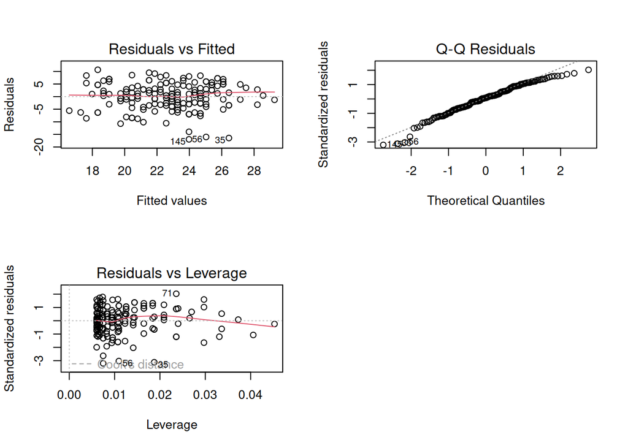

```r
par(mfrow = c(2,2))

# draw diagnostic plots using the plot() function. Choose the plots 1, 2 and 5
plot(model, which=c(1,2,5))
```

#### Interpretation

Starting from Residuals vs Fitted, we are looking for roughly a similar jitter pattern all throughout the plot. While a few outliers exist, it seems good overall. *The constant variance assumption is not violated*.

Q-Q plot should form approximately a straight line. Again, that is achieved. *The data follows roughly a normal distribution*.

Leverage tells us how much influence individual observations have on the model fit. I don’t see anything too alarming.

*Summary*: the model does not violate any underlying assumptions. However, it does not explain the phenomena (exam performance) that well, either.